# Assignment 10A: Sentiment Analysis

Code

Author

Patricio Romero

Published

November 15, 2026

# 1 Project Overview

The goal of this project is to explore sentiment analysis using R and Tidyverse. This project reproduces the main sentiment analysis methods presented in Chapter 2 of the book “Text Mining with R” by Julia Silge and David Robinson.

To extend the original analysis, I used a different text dataset related to electric vehicle reviews and included an additional sentiment lexicon.

As an electrical engineer, I am interested in understanding how people describe electric vehicle performance, battery life, driving range, and charging systems.

This project helps me understand how different sentiment lexicons can influence the results of text analysis.

# 2 Research Questions

1. What are the most common positive and negative words in electric vehicle reviews?
2. What is the overall sentiment of electric vehicle reviews?
3. How do sentiment analysis results vary across different sentiment lexicons?
4. How do the results from the electric vehicle dataset differ from the original Chapter 2 analysis?

# 3 Data Source

The dataset selected for this project is the Expert Review Dataset on Electric Quadricycles, available on Zenodo.

The dataset contains 95 reviews and three variables:

- Brand: Electric vehicle brand or model.
- URL: Original source of the review.
- Text: Full text of the vehicle review.

The Text column is the main variable used for sentiment analysis, while the Brand column identifies the different electric vehicle brands and models.

The Excel file contains five sheets. For this project, I selected only the “Original data” sheet to perform my own sentiment analysis using R.

**Source:** https://zenodo.org/records/14501242

## 3.1 Data Import

```r
library(tidyverse)
library(readxl)
library(knitr)
library(kableExtra)

# Import the original dataset
ev_reviews <- read_excel(
  "Data/Data Notes - Dataset.xlsx",
  sheet = "Original data"
)
```

The original dataset was imported from an Excel file. The following tables show the dataset dimensions, variable descriptions, and a preview of the data.

## 3.2 Dataset Overview

```r
# Create a dataset summary
dataset_summary <- tibble(
  Description = c(
    "Number of observations",
    "Number of variables",
    "Vehicle brands or models",
    "Data format",
    "Selected sheet"
  ),
  Value = c(
    nrow(ev_reviews),
    ncol(ev_reviews),
    n_distinct(ev_reviews$Brand, na.rm = TRUE),
    "Excel (.xlsx)",
    "Original data"
  )
)

dataset_summary %>%
  kable(
    caption = "Table 1. Dataset Overview",
    align = c("l", "c")
  ) %>%
  kable_styling(
    bootstrap_options = c("striped", "hover", "condensed"),
    full_width = FALSE,
    position = "center"
  )
```

Table 1. Dataset Overview

| Description | Value |
| --- | --- |
| Number of observations | 95 |
| Number of variables | 3 |
| Vehicle brands or models | 12 |
| Data format | Excel (.xlsx) |
| Selected sheet | Original data |

## 3.3 Variable Description

```r
# Describe the original variables
variable_description <- tibble(
  Variable = names(ev_reviews),
  Type = sapply(ev_reviews, class),
  Description = c(
    "Electric vehicle brand or model",
    "Original source of the review",
    "Full text of the vehicle review"
  )
)

variable_description %>%
  kable(
    caption = "Table 2. Variable Description",
    align = "l"
  ) %>%
  kable_styling(
    bootstrap_options = c("striped", "hover", "condensed"),
    full_width = FALSE,
    position = "center"
  )
```

Table 2. Variable Description

| Variable | Type | Description |
| --- | --- | --- |
| Brand | character | Electric vehicle brand or model |
| URL | character | Original source of the review |
| Text | character | Full text of the vehicle review |

## 3.4 Data Preview

```r
# Display the first six observations
ev_reviews %>%
  mutate(
    URL = str_trunc(URL, 45),
    Text = str_trunc(Text, 100)
  ) %>%
  head(6) %>%
  kable(
    caption = "Table 3. Electric Vehicle Reviews",
    align = "l"
  ) %>%
  kable_styling(
    bootstrap_options = c("striped", "hover", "condensed"),
    full_width = TRUE
  ) %>%
  column_spec(1, bold = TRUE) %>%
  column_spec(3, width = "15em")
```

Table 3. Electric Vehicle Reviews

| Brand | URL | Text |
| --- | --- | --- |
| Microlino | https://www.theverge.com/24093189/microlin... | Wow, what an entrance!” said a well-coiffed woman as other patrons seated at the sidewalk cafe, n... |
| Microlino | https://www.frandroid.com/survoltes/voitur... | The highly anticipated new electric car Microlino is finally arriving on the French market. The l... |
| Microlino | https://insideevs.com/reviews/714373/micro... | Americans don't like tiny cars. Some fear they may not be safe. Some think they'll look silly dri... |
| Microlino | https://www.electrifying.com/reviews/micro... | The Microlino is brainchild of Merlin Outober, who has steered the project through turbulent wate... |
| Microlino | https://www.caranddriver.com/reviews/a4375... | The city car is dead. While never particularly popular in the U.S., cars like the original Mini, ... |
| Microlino | https://www.theautopian.com/the-microlino-... | The Microlino ‘Electric BMW Isetta’ Is A Huge Piece Of Crap But I Still Love It. It’s been over s... |

# 4 Data Validation

Before performing sentiment analysis, the quality of the dataset was evaluated. This includes checking for missing values, duplicate records, and empty review texts.

Missing values are evaluated in this section, while duplicate records and empty reviews are checked during data preparation.

## 4.1 Missing Values

```r
# Check missing values by variable
missing_summary <- tibble(
  Variable = names(ev_reviews),
  `Missing Values` = colSums(is.na(ev_reviews)),
  Percentage = round(
    colMeans(is.na(ev_reviews)) * 100, 2
  )
)

missing_summary %>%
  kable(
    caption = "Table 4. Missing Values",
    align = c("l", "c", "c")
  ) %>%
  kable_styling(
    bootstrap_options = c("striped", "hover", "condensed"),
    full_width = FALSE,
    position = "center"
  )
```

Table 4. Missing Values

| Variable | Missing Values | Percentage |
| --- | --- | --- |
| Brand | 0 | 0 |
| URL | 0 | 0 |
| Text | 0 | 0 |

## 4.2 Reviews by Vehicle

```r
# Count reviews by vehicle brand or model
vehicle_summary <- ev_reviews %>%
  count(Brand, name = "Reviews", sort = TRUE) %>%
  mutate(
    Percentage = round(Reviews / sum(Reviews) * 100, 2)
  )

vehicle_summary %>%
  kable(
    caption = "Table 5. Number of Reviews by Vehicle",
    align = c("l", "c", "c")
  ) %>%
  kable_styling(
    bootstrap_options = c("striped", "hover", "condensed"),
    full_width = FALSE,
    position = "center"
  ) %>%
  column_spec(1, bold = TRUE)
```

Table 5. Number of Reviews by Vehicle

| Brand | Reviews | Percentage |
| --- | --- | --- |
| Microlino | 19 | 20.00 |
| XEV YOYO | 15 | 15.79 |
| Citroen Ami | 12 | 12.63 |
| Opel Rocks-e | 12 | 12.63 |
| Silence S04 | 11 | 11.58 |
| City Transformer | 7 | 7.37 |
| Fiat Topolino | 5 | 5.26 |
| Estrima Birò | 4 | 4.21 |
| DoGood | 3 | 3.16 |
| Eli Zero | 3 | 3.16 |
| SWAPA | 2 | 2.11 |
| Solar Squad EV | 2 | 2.11 |

The number of reviews may vary across vehicles. This is important to consider when comparing sentiment analysis results.

# 5 Original Analysis and Proposed Extension

## 5.1 Original Analysis

The original analysis is based on Chapter 2 of the book “Text Mining with R” by Julia Silge and David Robinson.

The authors use Jane Austen’s books to demonstrate how sentiment analysis works with tidy data. They use three sentiment lexicons: AFINN, Bing, and NRC.

I reproduced the main methods of the original analysis to understand how sentiment analysis works.

## 5.2 Proposed Extension

To extend the original analysis, I used a different dataset containing 95 electric vehicle reviews.

I also included the Loughran-McDonald lexicon as an additional sentiment lexicon.

This extension allows me to compare sentiment results using different types of text and sentiment lexicons.

# 6 Methodology

The analysis was developed in R using Tidyverse and tidytext.

The following steps were used:

1. Reproduce the main sentiment analysis methods from Chapter 2.
2. Import and validate the electric vehicle dataset.
3. Clean and prepare the text data.
4. Convert the text into individual words using tokenization.
5. Remove common words when appropriate.
6. Apply the AFINN, Bing, NRC, and Loughran-McDonald lexicons.
7. Normalize and compare sentiment scores across lexicons.
8. Create visualizations using ggplot2.
9. Compare the original analysis with the proposed extension.

## 6.1 Sentiment Lexicons

```r
lexicon_summary <- tibble(
  Lexicon = c(
    "AFINN",
    "Bing",
    "NRC",
    "Loughran-McDonald"
  ),
  Description = c(
    "Uses numerical sentiment scores from -5 to 5",
    "Classifies words as positive or negative",
    "Classifies words by sentiment and emotion",
    "Classifies words using financial sentiment categories"
  ),
  Purpose = c(
    "Original analysis",
    "Original analysis",
    "Original analysis",
    "Proposed extension"
  )
)

lexicon_summary %>%
  kable(
    caption = "Table 6. Sentiment Lexicons",
    align = "l"
  ) %>%
  kable_styling(
    bootstrap_options = c("striped", "hover", "condensed"),
    full_width = TRUE,
    position = "center"
  ) %>%
  column_spec(1, bold = TRUE)
```

Table 6. Sentiment Lexicons

| Lexicon | Description | Purpose |
| --- | --- | --- |
| AFINN | Uses numerical sentiment scores from -5 to 5 | Original analysis |
| Bing | Classifies words as positive or negative | Original analysis |
| NRC | Classifies words by sentiment and emotion | Original analysis |
| Loughran-McDonald | Classifies words using financial sentiment categories | Proposed extension |

Each lexicon uses a different method to score and classify words. For this reason, normalized values are used to facilitate the comparison of sentiment scores.

# 7 Expected Results

The initial expectation was to identify common positive and negative words in electric vehicle reviews and understand the overall sentiment of the dataset.

The comparison between the four sentiment lexicons was expected to show how different methods can produce different results using the same text.

# 8 Limitations

This project has some limitations:

- The dataset contains only 95 reviews.
- The number of reviews may vary across vehicles.
- The sentiment lexicons may not recognize some technical electrical and automotive terms.
- Sentiment analysis may not correctly identify sarcasm, negation, or the meaning of words in specific contexts.
- The Loughran-McDonald lexicon was designed for financial text, which may affect its results.

These limitations are considered when interpreting the final results.

# 9 Reproduction of the Original Analysis

This section reproduces the main sentiment analysis methods presented in Chapter 2 of the book “Text Mining with R” by Julia Silge and David Robinson.

The original analysis uses Jane Austen’s books and three sentiment lexicons: AFINN, Bing, and NRC.

The purpose of this section is to understand how sentiment analysis works before applying the same methods to the electric vehicle dataset.

## 9.1 Required Libraries

The following R packages are used to reproduce the original sentiment analysis and prepare the text data.

```r
library(tidytext)
library(janeaustenr)
library(textdata)
```

## 9.2 Sentiment Lexicons

The original analysis uses three sentiment lexicons: AFINN, Bing, and NRC. Each lexicon uses a different method to score or classify words.

```r
afinn <- get_sentiments("afinn")
bing <- get_sentiments("bing")
nrc <- get_sentiments("nrc")
```

```r
original_lexicon_summary <- tibble(
  Lexicon = c("AFINN", "Bing", "NRC"),
  Entries = c(
    nrow(afinn),
    nrow(bing),
    nrow(nrc)
  ),
  `Unique Words` = c(
    n_distinct(afinn$word),
    n_distinct(bing$word),
    n_distinct(nrc$word)
  ),
  Classification = c(
    "Numerical scores",
    "Positive and negative",
    "Sentiment and emotions"
  )
)

original_lexicon_summary %>%
  kable(
    caption = "Table 7. Original Sentiment Lexicons",
    align = c("l", "c", "c", "l"),
    format.args = list(big.mark = ",")
  ) %>%
  kable_styling(
    bootstrap_options = c("striped", "hover", "condensed"),
    full_width = FALSE,
    position = "center"
  ) %>%
  column_spec(1, bold = TRUE)
```

Table 7. Original Sentiment Lexicons

| Lexicon | Entries | Unique Words | Classification |
| --- | --- | --- | --- |
| AFINN | 2,477 | 2,477 | Numerical scores |
| Bing | 6,786 | 6,783 | Positive and negative |
| NRC | 13,872 | 6,453 | Sentiment and emotions |

## 9.3 Text Data Preparation

The original dataset contains six novels written by Jane Austen. The text is converted into a tidy format, with one word per row.

The book name, line number, and chapter number are preserved for the sentiment analysis.

```r
tidy_books <- austen_books() %>%
  group_by(book) %>%
  mutate(
    linenumber = row_number(),
    chapter = cumsum(
      str_detect(
        text,
        regex("^chapter [\\divxlc]",
              ignore_case = TRUE)
      )
    )
  ) %>%
  ungroup() %>%
  unnest_tokens(word, text)
```

```r
tidy_books %>%
  head(10) %>%
  kable(
    caption = "Table 8. Tokenized Text Data",
    align = c("l", "c", "c", "l")
  ) %>%
  kable_styling(
    bootstrap_options = c("striped", "hover", "condensed"),
    full_width = FALSE,
    position = "center"
  )
```

Table 8. Tokenized Text Data

| book | linenumber | chapter | word |
| --- | --- | --- | --- |
| Sense & Sensibility | 1 | 0 | sense |
| Sense & Sensibility | 1 | 0 | and |
| Sense & Sensibility | 1 | 0 | sensibility |
| Sense & Sensibility | 3 | 0 | by |
| Sense & Sensibility | 3 | 0 | jane |
| Sense & Sensibility | 3 | 0 | austen |
| Sense & Sensibility | 5 | 0 | 1811 |
| Sense & Sensibility | 10 | 1 | chapter |
| Sense & Sensibility | 10 | 1 | 1 |
| Sense & Sensibility | 13 | 1 | the |

The data is now ready for sentiment analysis. Each row contains a single word and its location in the original book.

## 9.4 Sentiment Analysis with Inner Join

The NRC lexicon is used to identify words associated with joy in the novel Emma.

The inner_join() function matches words from the original text with words in the sentiment lexicon.

```r
nrc_joy <- nrc %>%
  filter(sentiment == "joy")

emma_joy <- tidy_books %>%
  filter(book == "Emma") %>%
  inner_join(nrc_joy, by = "word") %>%
  count(word, sort = TRUE)

emma_joy %>%
  head(10) %>%
  kable(
    caption = "Table 9. Most Common Joy Words in Emma",
    col.names = c("Word", "Frequency"),
    align = c("l", "c")
  ) %>%
  kable_styling(
    bootstrap_options = c("striped", "hover", "condensed"),
    full_width = FALSE,
    position = "center"
  ) %>%
  column_spec(1, bold = TRUE)
```

Table 9. Most Common Joy Words in Emma

| Word | Frequency |
| --- | --- |
| good | 359 |
| friend | 166 |
| hope | 143 |
| happy | 125 |
| love | 117 |
| deal | 92 |
| found | 92 |
| present | 89 |
| kind | 82 |
| happiness | 76 |

The word “good” is the most common word associated with joy in the novel Emma, with 359 occurrences, followed by “friend” (166) and “hope” (143).

Other words, such as “happy” and “love”, are also associated with joy. However, some words may have different meanings depending on the context.

## 9.5 Sentiment Changes Across Novels

The Bing lexicon is used to examine how sentiment changes throughout Jane Austen’s six novels.

Each novel is divided into sections of 80 lines. The net sentiment is calculated by subtracting the number of negative words from the number of positive words.

```r
jane_austen_sentiment <- tidy_books %>%
  inner_join(bing, by = "word") %>%
  count(
    book,
    index = linenumber %/% 80,
    sentiment
  ) %>%
  pivot_wider(
    names_from = sentiment,
    values_from = n,
    values_fill = 0
  ) %>%
  mutate(sentiment = positive - negative)
```

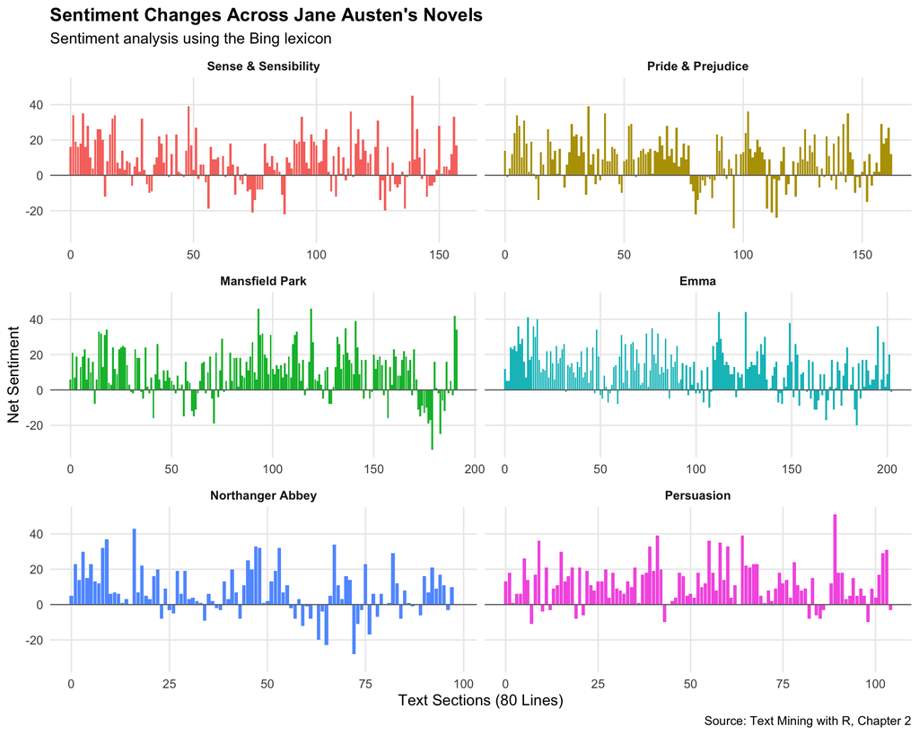

```r
ggplot(
  jane_austen_sentiment,
  aes(x = index, y = sentiment, fill = book)
) +
  geom_col(show.legend = FALSE) +
  geom_hline(
    yintercept = 0,
    color = "gray40",
    linewidth = 0.4
  ) +
  facet_wrap(
    ~book,
    ncol = 2,
    scales = "free_x"
  ) +
  labs(
    title = "Sentiment Changes Across Jane Austen's Novels",
    subtitle = "Sentiment analysis using the Bing lexicon",
    x = "Text Sections (80 Lines)",
    y = "Net Sentiment",
    caption = "Source: Text Mining with R, Chapter 2"
  ) +
  theme_minimal(base_size = 12) +
  theme(
    plot.title = element_text(face = "bold"),
    strip.text = element_text(face = "bold"),
    panel.grid.minor = element_blank()
  )
```

The visualization shows how sentiment changes throughout the six novels.

Positive values indicate that positive words are more frequent, while negative values indicate that negative words are more frequent.

Each novel shows different sentiment patterns as the story progresses.

## 9.6 Comparing the Three Sentiment Lexicons

This section compares the sentiment results from AFINN, Bing, and NRC using the novel Pride and Prejudice.

The same sections of 80 lines are used to compare how each lexicon measures sentiment.

```r
pride_prejudice <- tidy_books %>%
  filter(book == "Pride & Prejudice")
```

**AFINN Sentiment**

The sentiment score is calculated by adding the numerical values assigned to each word.

```r
afinn_comparison <- pride_prejudice %>%
  inner_join(afinn, by = "word") %>%
  group_by(index = linenumber %/% 80) %>%
  summarise(
    sentiment = sum(value),
    .groups = "drop"
  ) %>%
  mutate(method = "AFINN")
```

**Bing and NRC Sentiment**

The sentiment score is calculated by subtracting the number of negative words from the number of positive words.

```r
bing_nrc_comparison <- bind_rows(
  pride_prejudice %>%
    inner_join(bing, by = "word") %>%
    mutate(method = "Bing"),

  pride_prejudice %>%
    inner_join(
      nrc %>%
        filter(sentiment %in% c("positive", "negative")),
      by = "word",
      relationship = "many-to-many"
    ) %>%
    mutate(method = "NRC")
) %>%
  count(
    method,
    index = linenumber %/% 80,
    sentiment
  ) %>%
  pivot_wider(
    names_from = sentiment,
    values_from = n,
    values_fill = 0
  ) %>%
  mutate(sentiment = positive - negative)
```

**Sentiment Comparison**

The results from the three lexicons are combined and visualized to compare their sentiment patterns throughout the novel.

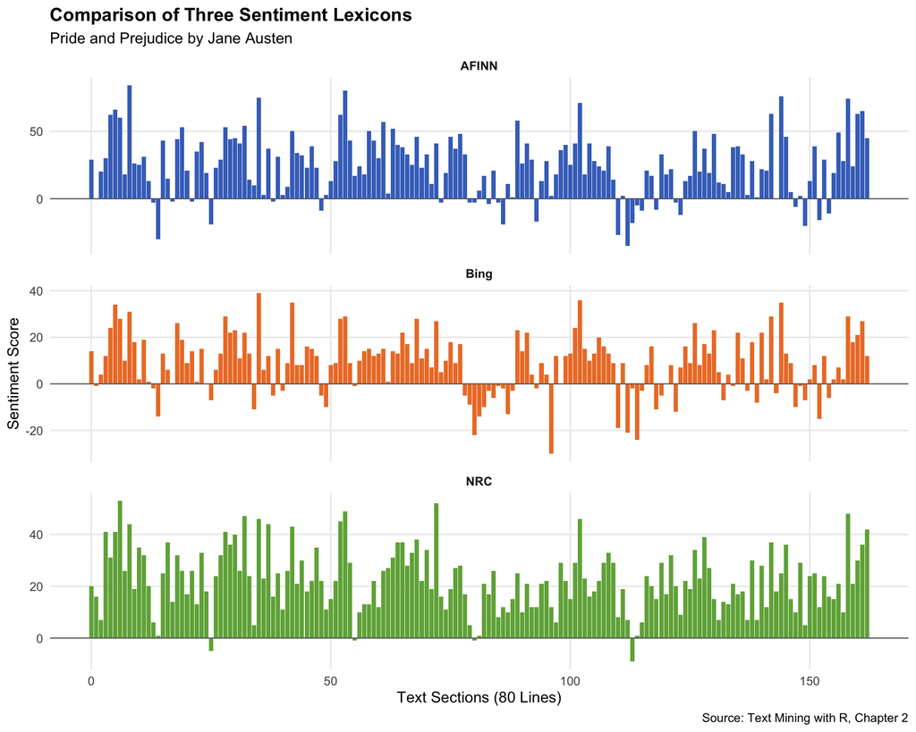

```r
original_comparison <- bind_rows(
  afinn_comparison,
  bing_nrc_comparison
)

ggplot(
  original_comparison,
  aes(x = index, y = sentiment, fill = method)
) +
  geom_col(show.legend = FALSE) +
  geom_hline(
    yintercept = 0,
    color = "gray40",
    linewidth = 0.4
  ) +
  facet_wrap(
    ~method,
    ncol = 1,
    scales = "free_y"
  ) +
  scale_fill_manual(
    values = c(
      "AFINN" = "#4472C4",
      "Bing" = "#ED7D31",
      "NRC" = "#70AD47"
    )
  ) +
  labs(
    title = "Comparison of Three Sentiment Lexicons",
    subtitle = "Pride and Prejudice by Jane Austen",
    x = "Text Sections (80 Lines)",
    y = "Sentiment Score",
    caption = "Source: Text Mining with R, Chapter 2"
  ) +
  theme_minimal(base_size = 12) +
  theme(
    plot.title = element_text(face = "bold"),
    strip.text = element_text(face = "bold"),
    panel.grid.minor = element_blank()
  )
```

The three sentiment lexicons show similar patterns throughout the novel, but their sentiment scores are different.

AFINN produces larger changes in sentiment, while Bing shows lower sentiment values. NRC tends to classify the text more positively.

These results show that the selection of a sentiment lexicon can influence the final results of the analysis.

## 9.7 Most Common Positive and Negative Words

**Word Frequency Calculation**

```r
bing_word_counts <- tidy_books %>%
  inner_join(bing, by = "word") %>%
  count(word, sentiment, sort = TRUE) %>%
  ungroup()
```

**Positive and Negative Word Visualization**

The ten most frequent words from each sentiment category are selected and displayed in a bar chart.

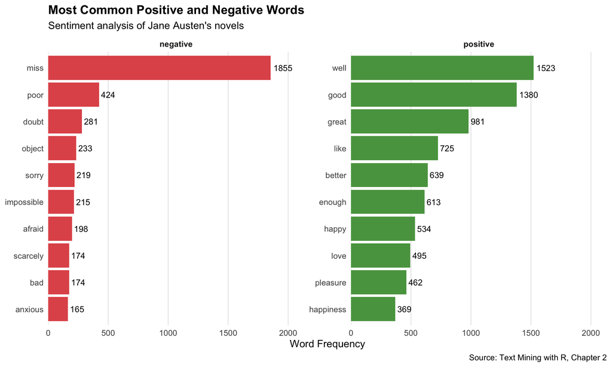

```r
bing_word_counts %>%
  group_by(sentiment) %>%
  slice_max(n, n = 10, with_ties = FALSE) %>%
  ungroup() %>%
  mutate(
    word = reorder(word, n)
  ) %>%
  ggplot(aes(x = n, y = word, fill = sentiment)) +
  geom_col(show.legend = FALSE) +
  geom_text(
    aes(label = n),
    hjust = -0.15,
    size = 3.5
  ) +
  facet_wrap(
    ~sentiment,
    scales = "free_y"
  ) +
  scale_fill_manual(
    values = c(
      "negative" = "#E15759",
      "positive" = "#59A14F"
    )
  ) +
  scale_x_continuous(
    expand = expansion(mult = c(0, 0.15))
  ) +
  labs(
    title = "Most Common Positive and Negative Words",
    subtitle = "Sentiment analysis of Jane Austen's novels",
    x = "Word Frequency",
    y = NULL,
    caption = "Source: Text Mining with R, Chapter 2"
  ) +
  theme_minimal(base_size = 12) +
  theme(
    plot.title = element_text(face = "bold"),
    strip.text = element_text(face = "bold"),
    panel.grid.minor = element_blank(),
    panel.grid.major.y = element_blank()
  )
```

The words “well”, “good”, and “great” are among the most frequent positive words.

The word “miss” is the most frequent word classified as negative. However, Jane Austen often uses this word as a title rather than a negative expression.

This example shows why the context of words is important when interpreting sentiment analysis results.

## 9.8 Custom Stop Words

Some words may be incorrectly classified because their meaning depends on the context. For example, the word “miss” is classified as negative by the Bing lexicon, but it is frequently used as a title in Jane Austen’s novels.

To reduce incorrect classifications, a custom stop words list is created and applied before updating the sentiment analysis.

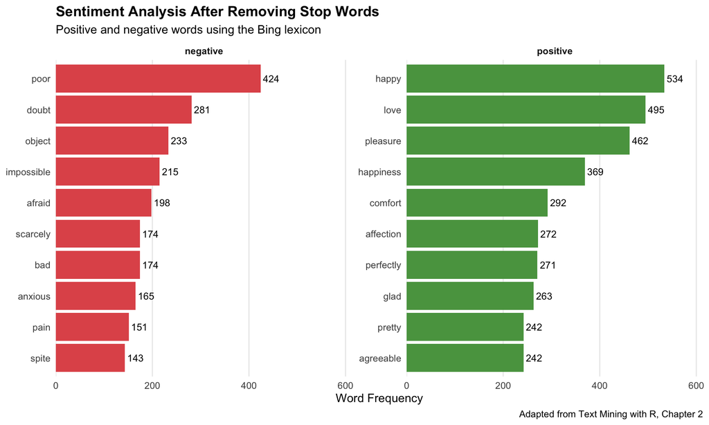

```r
# Create a custom stop words list
custom_stop_words <- bind_rows(
  tibble(
    word = "miss",
    lexicon = "custom"
  ),
  stop_words
)

# Remove stop words and calculate word frequencies
filtered_bing_counts <- tidy_books %>%
  anti_join(custom_stop_words, by = "word") %>%
  inner_join(bing, by = "word") %>%
  count(word, sentiment, sort = TRUE)

# Visualize the updated sentiment results
filtered_bing_counts %>%
  group_by(sentiment) %>%
  slice_max(n, n = 10, with_ties = FALSE) %>%
  ungroup() %>%
  mutate(word = reorder(word, n)) %>%
  ggplot(aes(x = n, y = word, fill = sentiment)) +
  geom_col(show.legend = FALSE) +
  geom_text(
    aes(label = n),
    hjust = -0.15,
    size = 3.5
  ) +
  facet_wrap(
    ~sentiment,
    scales = "free_y"
  ) +
  scale_fill_manual(
    values = c(
      "negative" = "#E15759",
      "positive" = "#59A14F"
    )
  ) +
  scale_x_continuous(
    expand = expansion(mult = c(0, 0.15))
  ) +
  labs(
    title = "Sentiment Analysis After Removing Stop Words",
    subtitle = "Positive and negative words using the Bing lexicon",
    x = "Word Frequency",
    y = NULL,
    caption = "Adapted from Text Mining with R, Chapter 2"
  ) +
  theme_minimal(base_size = 12) +
  theme(
    plot.title = element_text(face = "bold"),
    strip.text = element_text(face = "bold"),
    panel.grid.minor = element_blank(),
    panel.grid.major.y = element_blank()
  )
```

After removing the custom and standard stop words, the word “miss” is no longer included in the results. This shows the importance of understanding the context of words when performing sentiment analysis.

## 9.9 Word Clouds

Word clouds provide a visual representation of the most frequent words based on their sentiment.

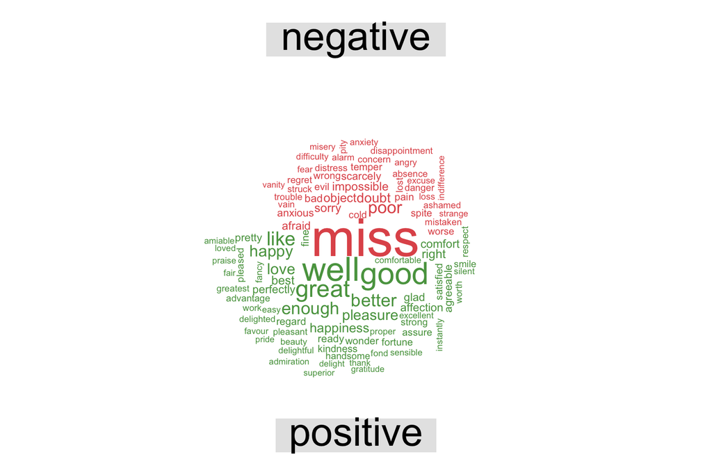

```r
library(wordcloud)

set.seed(123)

bing_word_counts %>%
  pivot_wider(
    names_from = sentiment,
    values_from = n,
    values_fill = 0
  ) %>%
  select(word, negative, positive) %>%
  column_to_rownames("word") %>%
  as.matrix() %>%
  comparison.cloud(
    colors = c("#E15759", "#59A14F"),
    max.words = 100
  )
```

The word cloud highlights the most frequent positive and negative words in Jane Austen’s novels. Larger words represent higher frequencies.

# 10 Electric Vehicle Sentiment Analysis

This section applies the sentiment analysis methods from Chapter 2 to the electric vehicle dataset.

The analysis uses four sentiment lexicons: AFINN, Bing, NRC, and Loughran-McDonald.

Before performing the analysis, the data is validated, cleaned, and converted into individual words.

```r
# Check duplicate records and empty reviews
duplicate_records <- sum(duplicated(ev_reviews))

empty_reviews <- sum(
  is.na(ev_reviews$Text) |
    str_trim(ev_reviews$Text) == ""
)

# Clean the original dataset
ev_clean <- ev_reviews %>%
  distinct() %>%
  filter(
    !is.na(Text),
    str_trim(Text) != ""
  ) %>%
  mutate(review_id = row_number())

# Tokenize the electric vehicle reviews
ev_words <- ev_clean %>%
  unnest_tokens(word, Text)

# Load the additional sentiment lexicon
loughran <- get_sentiments("loughran")

# Summarize data preparation
ev_preparation_summary <- tibble(
  Description = c(
    "Original reviews",
    "Duplicate records",
    "Empty reviews",
    "Valid reviews",
    "Total words",
    "Unique words"
  ),
  Value = c(
    nrow(ev_reviews),
    duplicate_records,
    empty_reviews,
    nrow(ev_clean),
    nrow(ev_words),
    n_distinct(ev_words$word)
  )
)

ev_preparation_summary %>%
  kable(
    caption = "Table 10. Electric Vehicle Data Preparation",
    align = c("l", "c"),
    format.args = list(big.mark = ",")
  ) %>%
  kable_styling(
    bootstrap_options = c("striped", "hover", "condensed"),
    full_width = FALSE,
    position = "center"
  )
```

Table 10. Electric Vehicle Data Preparation

| Description | Value |
| --- | --- |
| Original reviews | 95 |
| Duplicate records | 0 |
| Empty reviews | 0 |
| Valid reviews | 95 |
| Total words | 120,130 |
| Unique words | 8,633 |

The prepared dataset is used to answer the research questions and compare the results across the four sentiment lexicons.

## 10.1 Most Common Positive and Negative Words

The Bing lexicon is used to identify the most frequent positive and negative words in electric vehicle reviews. This helps us understand the main opinions expressed by reviewers.

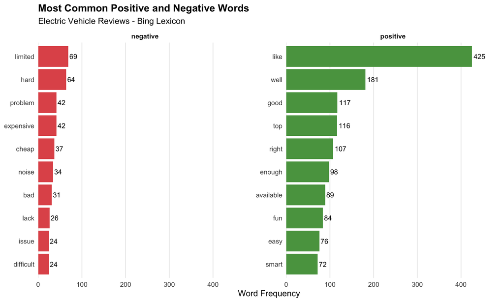

```r
# Calculate positive and negative word frequencies
ev_bing_counts <- ev_words %>%
  inner_join(bing, by = "word") %>%
  count(word, sentiment, sort = TRUE)

# Visualize the top 10 words for each sentiment
ev_bing_counts %>%
  group_by(sentiment) %>%
  slice_max(n, n = 10, with_ties = FALSE) %>%
  ungroup() %>%
  mutate(word = reorder(word, n)) %>%
  ggplot(aes(x = n, y = word, fill = sentiment)) +
  geom_col(show.legend = FALSE) +
  geom_text(
    aes(label = n),
    hjust = -0.15,
    size = 3.5
  ) +
  facet_wrap(
    ~sentiment,
    scales = "free_y"
  ) +
  scale_fill_manual(
    values = c(
      "negative" = "#E15759",
      "positive" = "#59A14F"
    )
  ) +
  scale_x_continuous(
    expand = expansion(mult = c(0, 0.15))
  ) +
  labs(
    title = "Most Common Positive and Negative Words",
    subtitle = "Electric Vehicle Reviews - Bing Lexicon",
    x = "Word Frequency",
    y = NULL
  ) +
  theme_minimal(base_size = 12) +
  theme(
    plot.title = element_text(face = "bold"),
    strip.text = element_text(face = "bold"),
    panel.grid.minor = element_blank(),
    panel.grid.major.y = element_blank()
  )
```

The results show the most frequent positive and negative words in electric vehicle reviews. Positive words may highlight vehicle strengths, while negative words may indicate problems and concerns. This analysis helps identify the main opinions expressed by electric vehicle reviewers.

## 10.2 Overall Sentiment of Electric Vehicle Reviews

The Bing lexicon is used to measure the overall sentiment of electric vehicle reviews by comparing the frequency of positive and negative words.

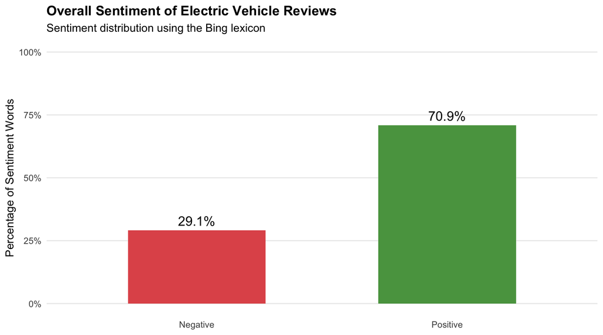

```r
# Calculate overall sentiment
ev_overall_sentiment <- ev_bing_counts %>%
  group_by(sentiment) %>%
  summarise(total = sum(n), .groups = "drop") %>%
  mutate(percentage = total / sum(total) * 100)

# Visualize overall sentiment
ggplot(
  ev_overall_sentiment,
  aes(x = sentiment, y = percentage, fill = sentiment)
) +
  geom_col(width = 0.55, show.legend = FALSE) +
  geom_text(
    aes(label = sprintf("%.1f%%", percentage)),
    vjust = -0.5,
    size = 5
  ) +
  scale_fill_manual(
    values = c(
      "negative" = "#E15759",
      "positive" = "#59A14F"
    )
  ) +
  scale_x_discrete(
    labels = c("Negative", "Positive")
  ) +
  scale_y_continuous(
    limits = c(0, 100),
    labels = scales::label_percent(scale = 1)
  ) +
  labs(
    title = "Overall Sentiment of Electric Vehicle Reviews",
    subtitle = "Sentiment distribution using the Bing lexicon",
    x = NULL,
    y = "Percentage of Sentiment Words"
  ) +
  theme_minimal(base_size = 12) +
  theme(
    plot.title = element_text(face = "bold"),
    panel.grid.major.x = element_blank(),
    panel.grid.minor = element_blank()
  )
```

According to the Bing lexicon, 70.9% of the words classified by sentiment are positive, while 29.1% are negative.

These results show that positive language is more frequent in the electric vehicle dataset. However, these percentages represent sentiment words, not the percentage of positive or negative reviews.

## 10.3 Comparison of the Four Sentiment Lexicons

To facilitate the comparison, AFINN scores are divided by five, while the other lexicons assign a value of +1 to positive words and -1 to negative words.

The net sentiment scores are then calculated per 100 words in the dataset.

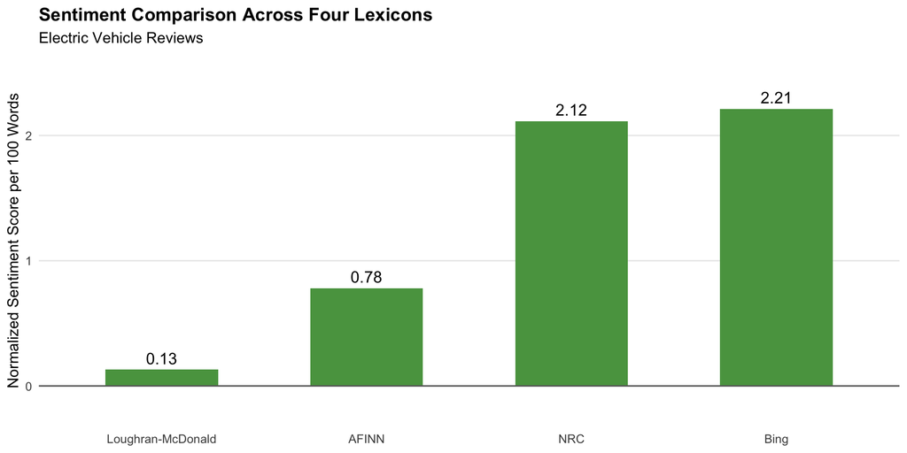

```r
# Calculate the total number of words
total_ev_words <- nrow(ev_words)

# AFINN sentiment scores
ev_afinn <- ev_words %>%
  inner_join(afinn, by = "word") %>%
  summarise(score = sum(value / 5)) %>%
  mutate(lexicon = "AFINN")

# Combine the categorical lexicons
categorical_lexicons <- bind_rows(
  bing %>% mutate(lexicon = "Bing"),
  nrc %>% mutate(lexicon = "NRC"),
  loughran %>% mutate(lexicon = "Loughran-McDonald")
) %>%
  filter(sentiment %in% c("positive", "negative"))

# Calculate categorical sentiment scores
ev_categorical <- ev_words %>%
  inner_join(
    categorical_lexicons,
    by = "word",
    relationship = "many-to-many"
  ) %>%
  mutate(
    value = if_else(sentiment == "positive", 1, -1)
  ) %>%
  group_by(lexicon) %>%
  summarise(score = sum(value), .groups = "drop")

# Normalize scores per 100 words
ev_lexicon_comparison <- bind_rows(
  ev_afinn,
  ev_categorical
) %>%
  mutate(
    normalized_score = score / total_ev_words * 100,
    sentiment = case_when(
  normalized_score > 0 ~ "Positive",
  normalized_score < 0 ~ "Negative",
  TRUE ~ "Neutral"
)
  )

# Visualize the sentiment scores
ggplot(
  ev_lexicon_comparison,
  aes(
    x = reorder(lexicon, normalized_score),
    y = normalized_score,
    fill = sentiment
  )
) +
  geom_col(width = 0.55, show.legend = FALSE) +
  geom_hline(yintercept = 0, color = "gray40") +
  geom_text(
    aes(
      label = sprintf("%.2f", normalized_score),
      vjust = if_else(normalized_score >= 0, -0.5, 1.5)
    ),
    size = 4.5
  ) +
  scale_fill_manual(
    values = c(
      "Positive" = "#59A14F",
      "Negative" = "#E15759"
    )
  ) +
  scale_y_continuous(
    expand = expansion(mult = c(0.15, 0.20))
  ) +
  labs(
    title = "Sentiment Comparison Across Four Lexicons",
    subtitle = "Electric Vehicle Reviews",
    x = NULL,
    y = "Normalized Sentiment Score per 100 Words"
  ) +
  theme_minimal(base_size = 12) +
  theme(
    plot.title = element_text(face = "bold"),
    panel.grid.major.x = element_blank(),
    panel.grid.minor = element_blank()
  )
```

All four sentiment lexicons produced positive sentiment scores. Bing obtained the highest normalized score (2.21), followed by NRC (2.12), AFINN (0.78), and Loughran-McDonald (0.13).

Loughran-McDonald produced the lowest score, possibly because it was designed for financial text.

These results show that different lexicons can produce different sentiment scores when analyzing the same dataset.

## 10.4 Comparison with the Original Analysis

The original analysis uses Jane Austen’s novels, while the proposed extension uses electric vehicle reviews.

Both datasets are analyzed using the Bing lexicon and normalized sentiment scores to account for differences in dataset size.

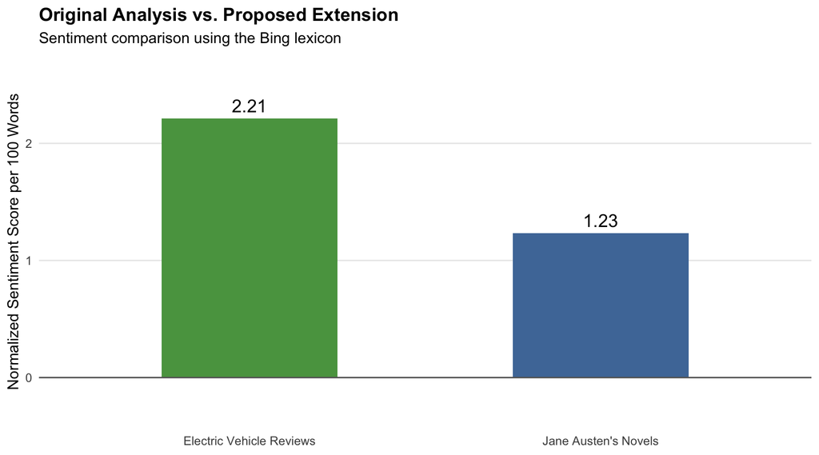

```r
# Combine both datasets
comparison_words <- bind_rows(
  tidy_books %>%
    select(word) %>%
    mutate(dataset = "Jane Austen's Novels"),
  ev_words %>%
    select(word) %>%
    mutate(dataset = "Electric Vehicle Reviews")
)

# Calculate total words in each dataset
dataset_totals <- comparison_words %>%
  count(dataset, name = "total_words")

# Calculate normalized sentiment scores
dataset_comparison <- comparison_words %>%
  inner_join(bing, by = "word") %>%
  mutate(
    value = if_else(sentiment == "positive", 1, -1)
  ) %>%
  group_by(dataset) %>%
  summarise(score = sum(value), .groups = "drop") %>%
  left_join(dataset_totals, by = "dataset") %>%
  mutate(
    normalized_score = score / total_words * 100
  )

# Visualize the comparison
ggplot(
  dataset_comparison,
  aes(
    x = dataset,
    y = normalized_score,
    fill = dataset
  )
) +
  geom_col(width = 0.5, show.legend = FALSE) +
  geom_hline(yintercept = 0, color = "gray40") +
  geom_text(
    aes(
      label = sprintf("%.2f", normalized_score),
      vjust = if_else(normalized_score >= 0, -0.5, 1.5)
    ),
    size = 5
  ) +
  scale_fill_manual(
    values = c(
      "Jane Austen's Novels" = "#4E79A7",
      "Electric Vehicle Reviews" = "#59A14F"
    )
  ) +
  scale_y_continuous(
    expand = expansion(mult = c(0.20, 0.25))
  ) +
  labs(
    title = "Original Analysis vs. Proposed Extension",
    subtitle = "Sentiment comparison using the Bing lexicon",
    x = NULL,
    y = "Normalized Sentiment Score per 100 Words"
  ) +
  theme_minimal(base_size = 12) +
  theme(
    plot.title = element_text(face = "bold"),
    panel.grid.major.x = element_blank(),
    panel.grid.minor = element_blank()
  )
```

Electric vehicle reviews produced a normalized sentiment score of 2.21, while Jane Austen’s novels produced a score of 1.23.

Both datasets show positive sentiment, but electric vehicle reviews obtained a higher score using the Bing lexicon.

These differences may be related to the vocabulary, context, and purpose of each dataset.

# 11 Conclusions

This project reproduced the main sentiment analysis methods presented in Chapter 2 of Text Mining with R and extended the analysis using 95 electric vehicle reviews.

The most frequent positive words were “like”, “well”, and “good”, while the most frequent negative words were “limited”, “hard”, “problem”, and “expensive”.

Using the Bing lexicon, 70.9% of the sentiment words were positive and 29.1% were negative.

All four sentiment lexicons produced positive scores. However, Bing obtained the highest normalized score (2.21), while Loughran-McDonald obtained the lowest (0.13).

The comparison with Jane Austen’s novels also showed that electric vehicle reviews obtained a higher normalized sentiment score.

Overall, this project demonstrates the importance of data preparation, word context, and lexicon selection. Sentiment analysis can be a useful tool for understanding reviewers’ opinions and identifying potential areas for improvement in the electric vehicle industry.

# 12 References

- Silge, J., & Robinson, D. (2017). *Text Mining with R: A Tidy Approach. Chapter 2: Sentiment Analysis with Tidy Data.*

  https://www.tidytextmining.com/sentiment.html
- Electric Vehicle Reviews Dataset. Zenodo.

  https://zenodo.org/records/14501242
- Tidytext: Text Mining Using dplyr, ggplot2, and Other Tidy Tools.

  https://juliasilge.github.io/tidytext/
- Textdata: Download and Load Various Text Datasets.

  https://cran.r-project.org/package=textdata
- R Project for Statistical Computing.

  https://www.r-project.org/
- Tidyverse.

  https://www.tidyverse.org/
- Loughran-McDonald Sentiment Word Lists.

  https://sraf.nd.edu/loughranmcdonald-master-dictionary/

# 13 Video Presentation

**DATA 607 – Week 10A: Sentiment Analysis**

Watch the video presentation on YouTube:

https://youtu.be/Ur47INpJnX4

# 14 Appendix: AI Assistance

ChatGPT was used to help understand the assignment requirements, organize the project, improve English writing, develop R code, and provide guidance on data preparation, sentiment analysis, visualizations, and interpretation of the results.

I selected the electric vehicle topic based on my professional background. I am responsible for running, reviewing, and verifying the R code, data transformations, analytical results, visualizations, and final conclusions.